# Hierarchical quantum architecture synthesis

Amy Rouillard<sup>1</sup>, Matt Lourens<sup>1</sup>, Prof Francesco Petruccione<sup>1,2,3</sup>

[figure not shown]

<sup>1</sup> Department of Physics, Stellenbosch University, South Africa  
<sup>2</sup> School for Data Science and Computational Thinking, Stellenbosch University, Stellenbosch, South Africa  
<sup>3</sup> National Institute for Theoretical and Computational Sciences (NITheCS), Stellenbosch, South Africa

## Motivation

[figure not shown]

Circuit representation of the quantum modular adder <sup>4</sup>

$$|c\rangle |a\rangle |b \rangle \rightarrow |c'\rangle |a\rangle |s = a+b \rangle$$

<sup>4</sup> Kim, Aeyoung, et al. "Quantum Modular Adder over GF (2 n− 1) without Saving the Final Carry." Applied Sciences 11.7 (2021): 2949.

## Outline

1. Introduction to Hierarqcal
2. Discrete optimization
3. Can we rediscover known quantum algorithms?
4. Outlook

## Introduction to Hierarqcal

[figure not shown]

### Hierarqcal motifs: Qcycle

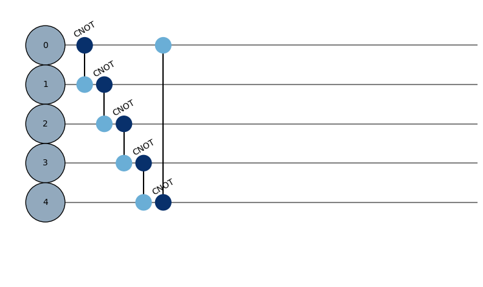

```python
circ = Qinit(5) + Qcycle(mapping = Cnot)

_ = plot_circuit(circ, plot_width=12)
```

### Hierarqcal motifs

1. Qcycle

2. Qpivot

3. Qmask and Qunmask

### Hierarqcal motifs: Qcycle

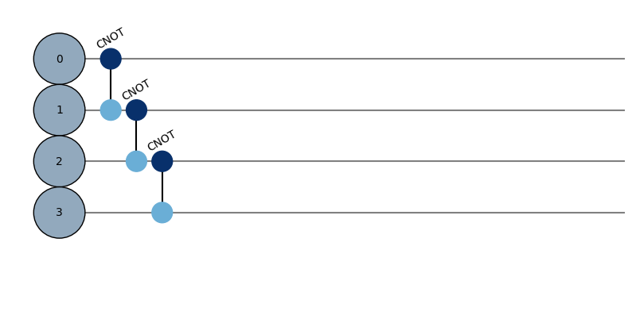

```python
circ = Qinit(4) + Qcycle(mapping = Cnot, boundary="open")

_ = plot_circuit(circ, plot_width=12)
```

### Hierarqcal motifs: Qpivot

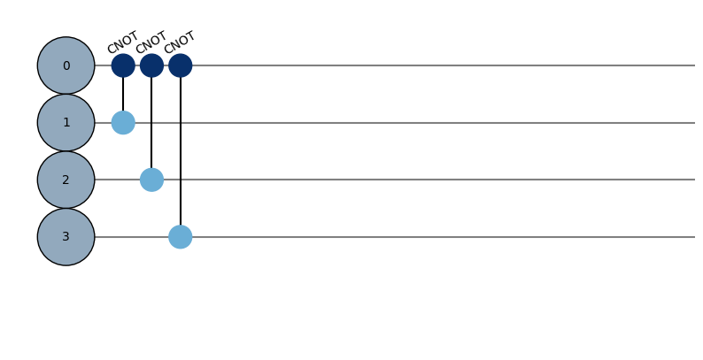

```python
circ = Qinit(4) + Qpivot(mapping = Cnot, global_pattern="1*")

_ = plot_circuit(circ, plot_width=12)
```

### Hierarqcal motifs: Composition (addition)

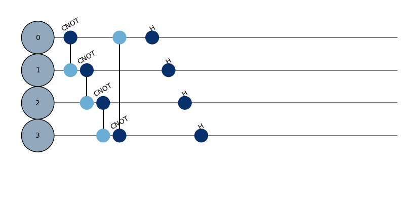

```python
circ = Qinit(4) + Qcycle(mapping = Cnot) + Qcycle(mapping = H)

_ = plot_circuit(circ, plot_width=12)
```

### Hierarqcal motifs: Qmask

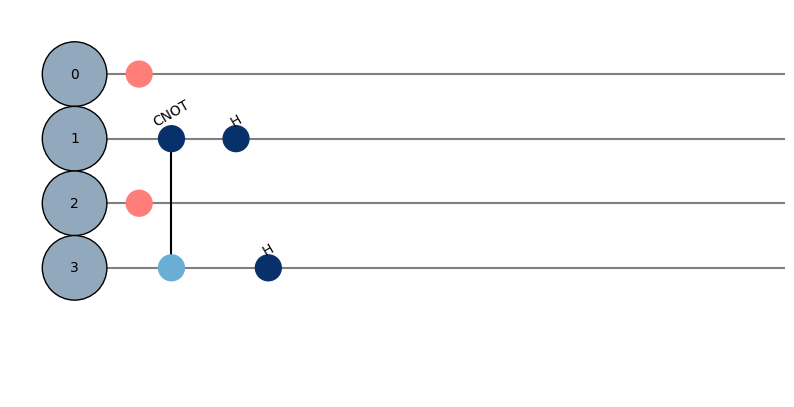

```python
circ = Qinit(4) + Qmask("10") + Qcycle(mapping = Cnot) + Qcycle(mapping = H)

_ = plot_circuit(circ, plot_width=12)
```

### Hierarqcal motifs: Qunmask

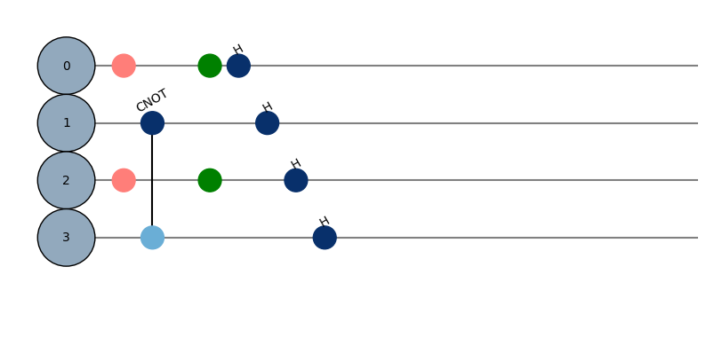

```python
motif = (Qmask("10") + Qcycle(mapping = Cnot)
         + Qunmask("previous") + Qcycle(mapping = H))
circ = Qinit(4) + motif
_ = plot_circuit(circ, plot_width=12)
```

### Hierarqcal motifs: Repetition (multiplication)

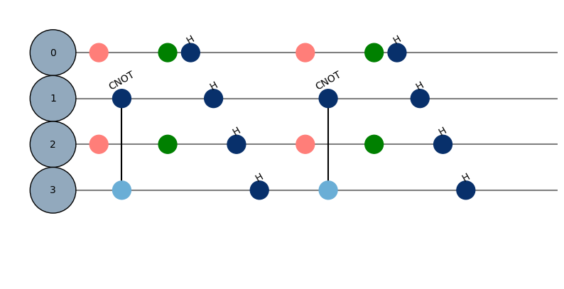

```python
motif = (Qmask("10") + Qcycle(mapping = Cnot)
         + Qunmask("previous") + Qcycle(mapping = H))
circ = Qinit(4) + motif*2
_ = plot_circuit(circ, plot_width=12)
```

### Hierarqcal motifs: building complex architectures

$$ |a_i \rangle |b_i \rangle |c \rangle \rightarrow |a_i \rangle | a_i \oplus b_i \rangle | a_i \land b_i \rangle $$

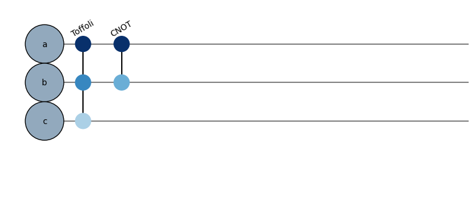

```python
add_bits = (
    Qcycle(mapping = Toffoli)
    + Qpivot(mapping = Cnot, global_pattern="1*", merge_within="11"))

circ = Qinit(['a','b','c']) + add_bits

_ = plot_circuit(circ, plot_width=12)
```

### Hierarqcal motifs: building complex architectures

$$ |a_i \rangle |b_i \rangle |c \rangle \rightarrow |a_i \rangle | a_i \oplus b_i \rangle | a_i \land b_i \rangle $$

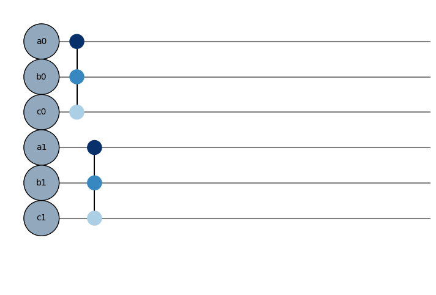

```python
circ = (Qinit(['a0','b0','c0','a1','b1','c1'])
    + Qcycle(mapping = Qinit(3) + add_bits, step = 3))

_ = plot_circuit(circ, plot_width=12)
```

## Discrete optimization

[figure not shown]

Schematic of Neural Architecture Search methods.<sup>5</sup>

<sup>5</sup>Elsken, T., Metzen, J. H. & Hutter, F. Neural architecture search: a survey. J. Mach. Learn. Res. 20, 1-21 (2019).

[figure not shown]

### Search space:

Hierarqcal motifs (Compositions of Qcycle, Qpivot, Qmask, Qunmask)

- are independent of the number of qubits
- have well defined discrete variables (e.g. mapping, boundary,...)

### Search strategy:

Discrete optimization algorithm

- Random search
- **Genetic algorithm**
- Annealing

[figure not shown]

### Performance estimate:

Fitness function

- Fidelity w.r.t. some target states, $|\langle y^{(i)} | U |x^{(i)} \rangle|$
- Classification performance score (accuracy, F1 score, etc.)
- Expectation value (e.g. energy)

Penalties for number of

- motifs
- gates
- parameters

### Genetic algorithm

```
# Initialize the population, a set of evaluated motifs
population = randomly_initialize_population()
# Select two members of the population to mutate
genotype1, genotype2 = tournament_selection(population)
```

[figure not shown]

### Genetic algorithm

```
# Generate new motifs
children = (
    crossover(genotype1, genotype2),
    mutation(genotype1),
    mutation(genotype2)
)
```

[figure not shown]

### Genetic algorithm

```
# Evaluate the fitness of the new motifs
for child in children:
    evaluate_genotypes(child)
# Update the population
population = update_population(children)
```

[figure not shown]

### Genetic algorithm

```
# Initialize the population, a set of evaluated motifs
population = randomly_initialize_population()
while fitness < threshold:
    # Select two members of the population to mutate
    genotype1, genotype2 = tournament_selection(population)
    # Generate new motifs
    children = (
        crossover(genotype1, genotype2),
        mutation(genotype1),
        mutation(genotype2)
    )
    # Evaluate the fitness of the new motifs
    for child in children:
        evaluate_genotypes(child)
    # Update the population
    population = update_population(children)
```

### Previous results - Quantum machine learning

[figure not shown]

Lourens, M., Sinayskiy, I., Park, D.K. et al. Hierarchical quantum circuit representations for neural architecture search. npj Quantum Inf 9, 79 (2023).

# Can we rediscover a known quantum algorithm?

### 2 bit logic gates $\neg x \wedge y$

[figure not shown]

## Quantum Fourier Transform

$ \sum_{j=0}^{2^n-1} z_j |j\rangle \rightarrow \frac{1}{\sqrt{2^n}} \sum^{N-1}_{k=0} \sum_{j=0}^{2^n-1} z_j e^{2\pi ijk/N}|k\rangle $

- Found motif should work correctly for arbitrary circuit sizes
- Repetitions (multiplication) should be learnt
- Training set: 2, 3 and 4 qubits
- Mappings include parameterized gates

## Quantum Fourier Transform

[figure not shown]

### Quantum Fourier Transform

Learnt architecture

```python
motif = nq*(
    Qpivot(mapping = CRx, global_pattern="1*")
    + Qcycle(mapping = H)
    + Qcycle(mapping = H, offset=1)
    + Qmask("1*")
)
```

### Quantum Fourier Transform

Parameters: 0.504 $\pi$

[figure not shown]

Parameters: 0.501 $\pi$, 0.244 $\pi$, 0.503 $\pi$

[figure not shown]

Parameters: 0.507 $\pi$, 0.257 $\pi$, 0.125 $\pi$, 0.513 $\pi$, 0.255 $\pi$, 0.495 $\pi$

[figure not shown]

### Quantum Fourier Transform

[figure not shown]

### Quantum Fourier Transform

Total runtime 15 hour 30 minutes

[figure not shown]

- total search space 58 million motifs (motif depth < 4)
- 3500 (0.006%) evaluations done

## Outlook

- Grover's search algorithm
- Exploit the circuit mapping hierarchy
- Understand the analytical properties of the motifs

# Thank you

[figure not shown]